# Prep for Anya and Wanshu

G. Moroz

3/23/2021

[source code on GitHub](https://github.com/agricolamz/prep_for_anya_and_wanshu)

# 1 Libraries

```r
library(tidyverse)
library(tidytext)
theme_set(theme_bw()) # for visualising
```

- `tidyverse` - a package with packages (most important for us are `readr`, `dplyr`, `ggplot2`, `stringr`)
- `tidytext` – is a nice package for the text analysis, see the [online book](https://www.tidytextmining.com/) by Julia Silge and David Robinson.

# 2 Files

```r
list.files()
```

```
##  [1] "andic_dicts.csv"
##  [2] "for_linearity_relation.png"
##  [3] "prep_for_anya_and_wanshu_cache"
##  [4] "prep_for_anya_and_wanshu_files"
##  [5] "prep_for_anya_and_wanshu.html"
##  [6] "prep_for_anya_and_wanshu.Rmd"
##  [7] "vowels_akhv1239.png"
##  [8] "vowels_andi1255.png"
##  [9] "vowels_bagv1239.png"
## [10] "vowels_botl1242 Alekseev 2006.png"
## [11] "vowels_botl1242 Saidova, Abusov 2012.png"
## [12] "vowels_cham1309.png"
## [13] "vowels_ghod1238.png"
## [14] "vowels_kara1474.png"
## [15] "vowels_tind1238.png"
```

Read file into R:

```r
read_csv("andic_dicts.csv") %>%
  filter(glottocode != "toki1238") ->
  andic
```

Have a look:

```r
glimpse(andic)
```

```
## Rows: 88,104
## Columns: 19
## $ lang                     <chr> "akhv1239", NA, NA, NA, NA, NA, NA, NA, NA, N…
## $ id_word                  <dbl> 1, 2, 3, 3, 3, 4, 5, 6, 7, 8, 9, 9, 10, 10, 1…
## $ id_meaning               <dbl> 1, 1, 1, 2, 3, 1, 1, 1, 1, 1, 1, 2, 1, 2, 1, …
## $ id                       <dbl> 1, 2, 3, 4, 5, 6, 7, 8, 9, 10, 11, 12, 13, 14…
## $ lemma                    <chr> "аба'далIи", "а/б/а'жве", "а/б/ажу'рулъIа", "…
## $ ipa                      <chr> "a-b-'a-d-a-tɬː-i", "a-b-'a-ʒʷ-e", "a-b-a-ʒ-'…
## $ morphology               <chr> NA, "(-ролIи)", "(абажвари', аба-жу'ва, абажв…
## $ bor                      <dbl> NA, NA, NA, NA, NA, NA, NA, NA, NA, NA, NA, N…
## $ annotator                <chr> "Arseniy Averin", "Arseniy Averin", "Arseniy …
## $ pos                      <chr> "adj", "noun", "verb", "verb", "verb", "noun"…
## $ concepticon              <chr> "everlasting", "sociability", NA, NA, NA, NA,…
## $ meaning_ru               <chr> "вечный", "общительность", "общаться", "привя…
## $ definition               <chr> "вечный; нескончаемый; *абадалIи чIили* загро…
## $ glottocode               <chr> "akhv1239", "akhv1239", "akhv1239", "akhv1239…
## $ reference                <chr> "Magomedova, Abdulayeva 2007", "Magomedova, A…
## $ comments                 <lgl> NA, NA, NA, NA, NA, NA, NA, NA, NA, NA, NA, N…
## $ borrowing_source_word    <chr> NA, NA, NA, NA, NA, NA, NA, NA, NA, NA, NA, N…
## $ borrowing_source_comment <lgl> NA, NA, NA, NA, NA, NA, NA, NA, NA, NA, NA, N…
## $ source                   <lgl> NA, NA, NA, NA, NA, NA, NA, NA, NA, NA, NA, N…
```

# 3 Extract singleton segment frequencies

Convert dataset to the table with one segment per row:

```r
andic %>%
  filter(is.na(bor)) %>%
  mutate(glottocode = ifelse(glottocode == "botl1242", str_c(glottocode, " ", reference), glottocode)) %>%
  distinct(ipa, glottocode) %>%
  mutate(id = 1:n()) %>%
  unnest_tokens(output = "segment", input = ipa, token = stringr::str_split, pattern = "-", drop = FALSE) %>%
  filter(!is.na(segment)) ->
  unnested_andic
glimpse(unnested_andic)
```

```
## Rows: 383,729
## Columns: 4
## $ ipa        <chr> "a-b-'a-d-a-tɬː-i", "a-b-'a-d-a-tɬː-i", "a-b-'a-d-a-tɬː-i",…
## $ glottocode <chr> "akhv1239", "akhv1239", "akhv1239", "akhv1239", "akhv1239",…
## $ id         <int> 1, 1, 1, 1, 1, 1, 1, 2, 2, 2, 2, 2, 3, 3, 3, 3, 3, 3, 3, 3,…
## $ segment    <chr> "a", "b", "'a", "d", "a", "tɬː", "i", "a", "b", "'a", "ʒʷ",…
```

In case we want to change something in our segments, use `case_when` and create a new dataframe, e. g. `unnested_andic_front_back`.

```r
unnested_andic %>%
  # THIS CAUSE MULTIPLE TRUBLES!!! (30.09.2021)
  #distinct(ipa, glottocode, segment) %>% # remove repetitions
  filter(str_detect(segment, "[aoiue]")) %>%
  mutate(segment2 = case_when(
    str_detect(segment, "[ie]") ~ "front",
    str_detect(segment, "a") ~ "mid",
    str_detect(segment, "[uo]") ~ "back")) ->
  unnested_andic_featured
glimpse(unnested_andic_featured)
```

```
## Rows: 172,394
## Columns: 5
## $ ipa        <chr> "a-b-'a-d-a-tɬː-i", "a-b-'a-d-a-tɬː-i", "a-b-'a-d-a-tɬː-i",…
## $ glottocode <chr> "akhv1239", "akhv1239", "akhv1239", "akhv1239", "akhv1239",…
## $ id         <int> 1, 1, 1, 1, 2, 2, 2, 3, 3, 3, 3, 3, 4, 4, 4, 5, 5, 5, 5, 5,…
## $ segment    <chr> "a", "'a", "a", "i", "a", "'a", "e", "a", "a", "'u", "u", "…
## $ segment2   <chr> "mid", "mid", "mid", "front", "mid", "mid", "front", "mid",…
```

Extract singleton segment frequencies

```r
unnested_andic_featured %>%
  count(glottocode, segment2) %>%
  group_by(glottocode) %>%
  mutate(overall = sum(n),
         ratio = n/overall) ->
  unnested_andic_featured_frequencies
glimpse(unnested_andic_featured_frequencies)
```

```
## Rows: 27
## Columns: 5
## Groups: glottocode [9]
## $ glottocode <chr> "akhv1239", "akhv1239", "akhv1239", "andi1255", "andi1255",…
## $ segment2   <chr> "back", "front", "mid", "back", "front", "mid", "back", "fr…
## $ n          <int> 6686, 9871, 10113, 6208, 5589, 3940, 3485, 6203, 11674, 455…
## $ overall    <int> 26670, 26670, 26670, 15737, 15737, 15737, 21362, 21362, 213…
## $ ratio      <dbl> 0.2506937, 0.3701162, 0.3791901, 0.3944843, 0.3551503, 0.25…
```

We can look at it:

```r
unnested_andic_featured_frequencies %>%
  select(-n, -overall) %>%
  pivot_wider(names_from = glottocode, values_from = ratio)
```

| segment2 | akhv1239 | andi1255 | bagv1239 | botl1242 Alekseev 2006 | botl1242 Saidova, Abusov 2012 | cham1309 | ghod1238 | kara1474 | tind1238 |
| --- | --- | --- | --- | --- | --- | --- | --- | --- | --- |
| back | 0.2506937 | 0.3944843 | 0.1631402 | 0.1967291 | 0.1841622 | 0.1772668 | 0.1943781 | 0.1843039 | 0.1569448 |
| front | 0.3701162 | 0.3551503 | 0.2903754 | 0.3687322 | 0.3595519 | 0.2703849 | 0.3994678 | 0.2881318 | 0.3000682 |
| mid | 0.3791901 | 0.2503654 | 0.5464844 | 0.4345387 | 0.4562859 | 0.5523483 | 0.4061541 | 0.5275643 | 0.5429870 |

Or even try to visualize:

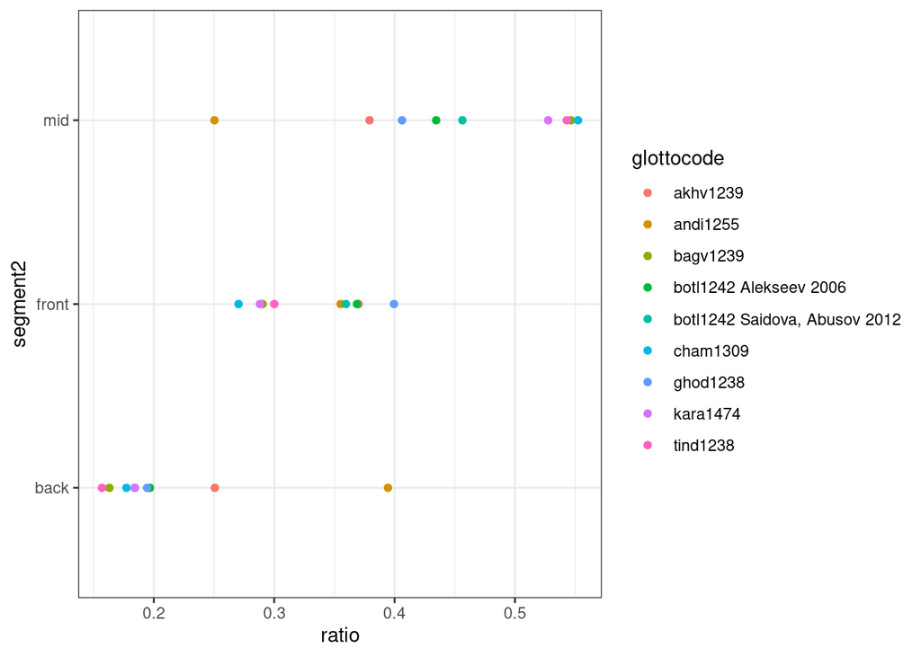

```r
unnested_andic_featured_frequencies %>%
  group_by(segment2) %>%  # this and next 3 lines are for ordering segments
  mutate(mean_ratio = mean(ratio, na.rm = TRUE)) %>%
  ungroup() %>%
  mutate(segment2 = fct_reorder(segment2, mean_ratio)) %>%
  top_n(100) %>%
  ggplot(aes(ratio, segment2, color = glottocode))+
  geom_point()
```

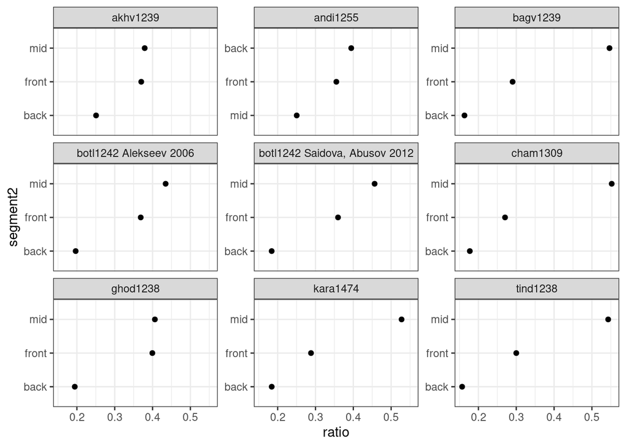

```r
unnested_andic_featured_frequencies %>%
  mutate(segment2 = reorder_within(segment2, ratio, glottocode)) %>%
  group_by(glottocode) %>%
  top_n(25) %>%
  ggplot(aes(ratio, segment2))+
  geom_point()+
  facet_wrap(~glottocode, scales = "free_y")+
  scale_y_reordered()
```

# 4 Extract combined segment frequencies

There are two types of combined segment frequencies:

- **[“bag of words”](https://en.wikipedia.org/wiki/Bag-of-words_model) approach**: simple calculation number of words that have selected pair of sounds
- **[markov chain](https://en.wikipedia.org/wiki/Markov_chain) approach** more like Markov Chain approach, where you model number of cases when one segment is following another

For a moment I will work with the first option, but lets keep the second in mind.

## 4.1 “Bag of words” approach

```r
unnested_andic_featured %>%
  select(-segment) %>%
  group_by(glottocode, ipa) %>%
  nest(data = segment2) %>%
  mutate(data = map(data, unlist),
         data = map(data, table),
         data2 = map(data, names),
         data2 = map(data2, unlist),
         data = map(data, function(x) x[x > 1]),
         data = map(data, names),
         data3 = map2(data, data2, function(x, y){c(unlist(x), unlist(y))}),
         data3 = map(data3, sort),
         length = map_dbl(data3, length)) %>%
  filter(length > 1) %>%
  mutate(pairs = map(data3, combn, m = 2, FUN = str_c, collapse = " "),
         pairs = map(pairs, unique)) %>%
  unnest_longer(pairs) %>%
  ungroup() %>%
  count(glottocode, pairs, sort = TRUE) %>%
  separate(pairs, into = c("segment_1", "segment_2"), sep = " ", remove = FALSE) ->
  pairs
```

```r
glimpse(pairs)
```

```
## Rows: 54
## Columns: 5
## $ glottocode <chr> "akhv1239", "tind1238", "botl1242 Alekseev 2006", "tind1238…
## $ pairs      <chr> "front mid", "front mid", "front mid", "mid mid", "mid mid"…
## $ segment_1  <chr> "front", "front", "front", "mid", "mid", "front", "mid", "b…
## $ segment_2  <chr> "mid", "mid", "mid", "mid", "mid", "mid", "mid", "mid", "mi…
## $ n          <int> 4452, 3996, 3892, 3862, 3642, 3447, 3183, 3031, 3018, 2962,…
```

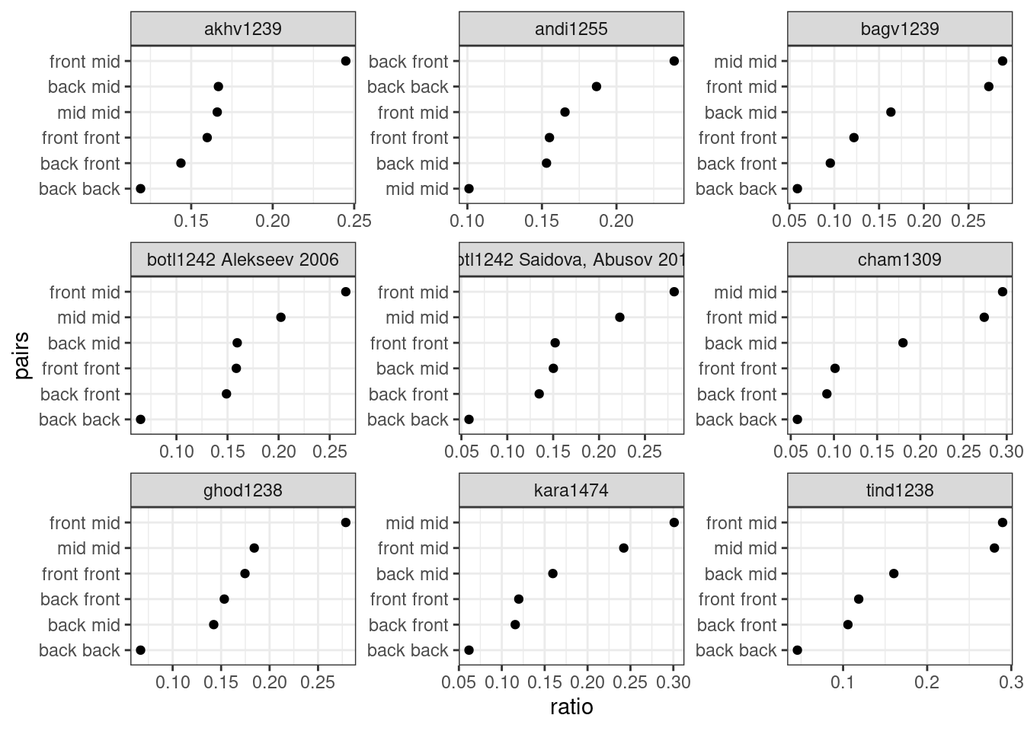

```r
pairs %>%
  group_by(glottocode) %>%
  mutate(overall = sum(n),
         ratio = n/overall) %>%
  top_n(20) %>%
  mutate(pairs = reorder_within(pairs, ratio, glottocode)) %>%
  ggplot(aes(ratio, pairs))+
  geom_point()+
  facet_wrap(~glottocode, scales = "free")+
  scale_y_reordered()
```

Remember that order in each pair does not reflect order in the word, otherwise we could have deal with pairs with different order (a-r vs r-a). It is important to have a good `unnested_andic_featured` dataframe: you need to filter out consonant/vowels and create the correct `segment2` column.

## 4.2 Markov chain approach

Since in this approach we want to model changes from one segment to another, the easiest way to do it is to add hash sign `#`, that denotes the end of the word.

```r
andic %>%
  filter(is.na(bor)) %>%
  mutate(glottocode = ifelse(glottocode == "botl1242", str_c(glottocode, " ", reference), glottocode)) %>%
  distinct(ipa, glottocode) %>%
  mutate(id = 1:n(),
         ipa = str_c(ipa, "-#")) %>%
  unnest_tokens(output = "segment", input = ipa, token = stringr::str_split, pattern = "-", drop = FALSE) %>%
  filter(!is.na(segment)) %>%
  filter(str_detect(segment, "[aoiue\\#]")) %>%
  mutate(segment = case_when(
    str_detect(segment, "[ie]") ~ "front",
    str_detect(segment, "a") ~ "mid",
    str_detect(segment, "[uo]") ~ "back",
    str_detect(segment, "\\#") ~ "#")) %>%
  mutate(next_segment = lead(segment)) %>%
  filter(segment != "#",
         next_segment != "#") %>%
  count(glottocode, segment, next_segment) ->
  unnested_andic_featured_with_hash
```

And now we can do more or less the same vizualisations as in previous section:

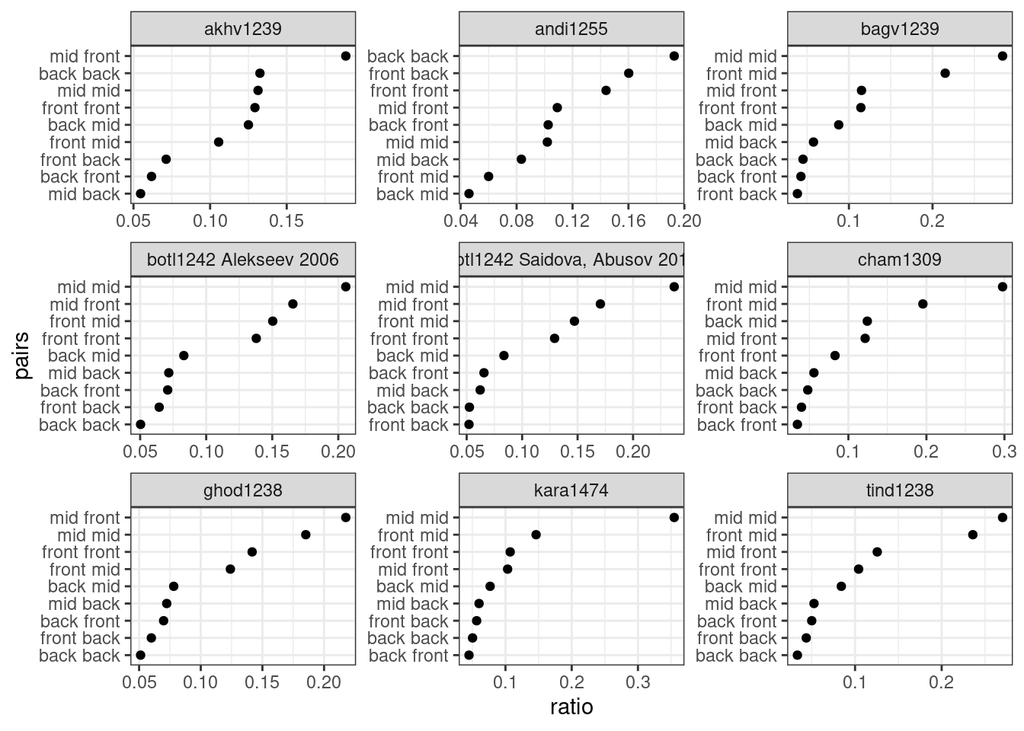

```r
unnested_andic_featured_with_hash %>%
  mutate(pairs = str_c(segment, " ", next_segment)) %>%
  group_by(glottocode) %>%
  mutate(overall = sum(n),
         ratio = n/overall) %>%
  top_n(20) %>%
  mutate(pairs = reorder_within(pairs, ratio, glottocode)) %>%
  ggplot(aes(ratio, pairs))+
  geom_point()+
  facet_wrap(~glottocode, scales = "free")+
  scale_y_reordered()
```

# 5 Combine everything

So for now we have tow tables:

- `pairs` (“Bag of words” approach)

```r
pairs %>%
  slice(1:5)
```

| glottocode | pairs | segment_1 | segment_2 | n |
| --- | --- | --- | --- | --- |
| akhv1239 | front mid | front | mid | 4452 |
| tind1238 | front mid | front | mid | 3996 |
| botl1242 Alekseev 2006 | front mid | front | mid | 3892 |
| tind1238 | mid mid | mid | mid | 3862 |
| bagv1239 | mid mid | mid | mid | 3642 |

- `unnested_andic_with_hash` (Markov-chain approach)

```r
unnested_andic_featured_with_hash %>%
  slice(1:5)
```

| glottocode | segment | next_segment | n |
| --- | --- | --- | --- |
| akhv1239 | back | back | 2559 |
| akhv1239 | back | front | 1193 |
| akhv1239 | back | mid | 2414 |
| akhv1239 | front | back | 1377 |
| akhv1239 | front | front | 2496 |

Lets create a dataframe with pure counts:

```r
unnested_andic_featured %>%
  count(glottocode, segment2) %>%
  rename(raw_n = n,
         segment = segment2) %>%
  group_by(glottocode) %>%
  mutate(frequency = raw_n/sum(raw_n)) %>%
  select(-raw_n) ->
  pure_counts
```

We want to combine them together and connect with pure probabilities:

```r
pairs %>%
  rename(segment = segment_1,
         next_segment = segment_2) %>%
  full_join(pure_counts) %>%
  rename(f1 = frequency) %>%
  full_join(pure_counts, by = c("glottocode" = "glottocode", "next_segment" = "segment")) %>%
  rename(f2 = frequency) %>%
  group_by(glottocode) %>%
  mutate(observed_probability = n/sum(n, na.rm = TRUE),
         multiply = segment != next_segment,
         expected_probability = f1*f2,
         expected_probability = ifelse(multiply, expected_probability*2, expected_probability),
         method = "bag of words") %>%
  select(glottocode, pairs, observed_probability, expected_probability, method) ->
  probabilities_bag_of_words
glimpse(probabilities_bag_of_words)
```

```
## Rows: 54
## Columns: 5
## Groups: glottocode [9]
## $ glottocode           <chr> "akhv1239", "tind1238", "botl1242 Alekseev 2006",…
## $ pairs                <chr> "front mid", "front mid", "front mid", "mid mid",…
## $ observed_probability <dbl> 0.2448441, 0.2896702, 0.2657381, 0.2799565, 0.287…
## $ expected_probability <dbl> 0.28068883, 0.32586629, 0.32045683, 0.29483493, 0…
## $ method               <chr> "bag of words", "bag of words", "bag of words", "…
```

```r
unnested_andic_featured_with_hash %>%
  full_join(pure_counts) %>%
  rename(f1 = frequency) %>%
  full_join(pure_counts, by = c("glottocode" = "glottocode", "next_segment" = "segment")) %>%
  rename(f2 = frequency) %>%
  group_by(glottocode) %>%
  mutate(observed_probability = n/sum(n, na.rm = TRUE),
         expected_probability = f1*f2,
         method = "markov chain",
         pairs = str_c(segment, " ", next_segment)) %>%
  select(glottocode, pairs, observed_probability, expected_probability, method) ->
  probabilities_markov_chain
glimpse(probabilities_markov_chain)
```

```
## Rows: 81
## Columns: 5
## Groups: glottocode [9]
## $ glottocode           <chr> "akhv1239", "akhv1239", "akhv1239", "akhv1239", "…
## $ pairs                <chr> "back back", "back front", "back mid", "front bac…
## $ observed_probability <dbl> 0.13252887, 0.06178466, 0.12501942, 0.07131390, 0…
## $ expected_probability <dbl> 0.06284731, 0.09278579, 0.09506056, 0.09278579, 0…
## $ method               <chr> "markov chain", "markov chain", "markov chain", "…
```

And now everything can be merged:

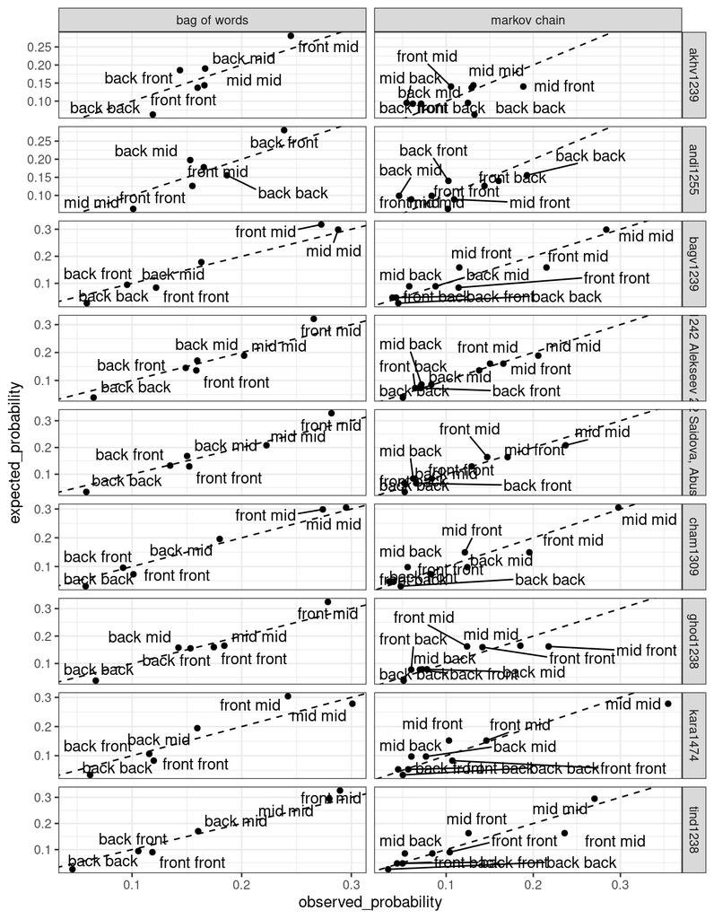

```r
probabilities_bag_of_words %>%
  bind_rows(probabilities_markov_chain) %>%
  ggplot(aes(observed_probability, expected_probability, label = pairs))+
  geom_point()+
  ggrepel::geom_text_repel()+
  geom_abline(intercept = 0, slope = 1, linetype = 2) +
  facet_grid(glottocode~method, scales = "free")
```

Hurrah! Dots are around the `y = x` line!